# Session 2 — Neighbours and Spatial Weights

Contiguity · k-nearest · weights · the spatial lag · sensitivity · Lab 2

Community Medicine Workshop

## Where we are

- Session 1: spatial data, CRS, joins, honest maps
- Every spatial test asks: **are neighbouring areas more alike than chance?**
- First we must **define “neighbour”**. That definition is the **spatial weights matrix**, the most influential choice in the analysis
- By the end you can:
  - build **queen, rook, k-nearest** and **distance** neighbours
  - turn them into **row-standardised weights**
  - compute and read a **spatial lag**
  - check how sensitive a result is to the choice

# Topic 1 — Who is a neighbour?

## Contiguity: share a boundary

- **Rook:** share an **edge**
- **Queen:** share an edge **or a corner** (the usual default)
- Needs polygons; areas of similar size behave best
- Watch for **islands**: areas with no neighbour

```r
nb_q <- poly2nb(blocks, queen = TRUE,  snap = 1e-4)
nb_r <- poly2nb(blocks, queen = FALSE, snap = 1e-4)
c(queen_links = sum(card(nb_q)), rook_links = sum(card(nb_r)))
```

```
queen_links  rook_links
        414         414
```

```r
summary(nb_q)
```

```
Neighbour list object:
Number of regions: 79
Number of nonzero links: 414
Percentage nonzero weights: 6.633552
Average number of links: 5.240506
Link number distribution:

 2  3  4  5  6  7  8
 1  7 13 20 28  9  1
1 least connected region:
3 with 2 links
1 most connected region:
24 with 8 links
```

## Seeing the links

```r
cen <- st_coordinates(st_centroid(blocks))
plot(st_geometry(blocks), border = "grey70", main = "Queen contiguity")
plot(nb_q, cen, add = TRUE, col = "red", pch = 19, cex = 0.4)
```

Check three things in `summary()`: the **average number of neighbours** (about 5 here), the **least and most connected** blocks, and any **isolates** (they break most tests unless `zero.policy = TRUE`).

## Seeing the links

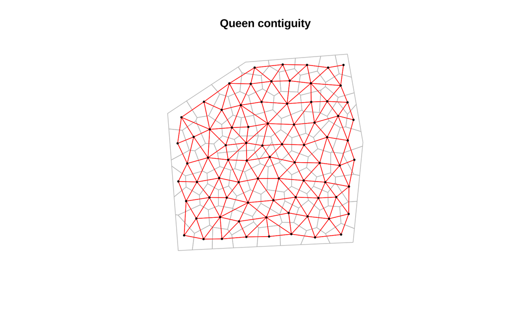

## Distance and k-nearest neighbours

```r
knn5 <- knn2nb(knearneigh(cen, k = 5))
d <- unlist(nbdists(knn2nb(knearneigh(cen, k = 1)), cen))
nb_d <- dnearneigh(cen, 0, max(d))
par(mfrow = c(1, 2))
plot(st_geometry(blocks), border = "grey80", main = "5 nearest neighbours"); plot(knn5, cen, add = TRUE, col = "blue", pch = 19, cex = 0.3)
plot(st_geometry(blocks), border = "grey80", main = "Distance band"); plot(nb_d, cen, add = TRUE, col = "darkgreen", pch = 19, cex = 0.3)
```

| Definition | Neighbours per area | Good for | Watch out for |
| --- | --- | --- | --- |
| Queen / rook | varies | polygons of similar size | islands; large areas have many neighbours |
| k nearest | exactly k | unequal areas, points | links across a gap that are not real |
| Distance band | varies | points, a travel-distance idea | too short: isolates; too long: everyone linked |

## Distance and k-nearest neighbours

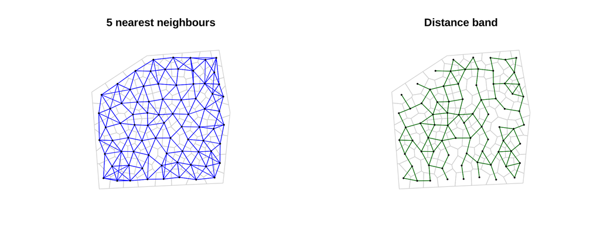

# Topic 2 — From neighbours to weights

## A neighbour list says who; weights say how much

| Style | Meaning |
| --- | --- |
| `"B"` binary | 1 for every neighbour |
| `"W"` **row-standardised** | each area’s weights sum to 1; the usual choice |
| `"S"` | variance-stabilising |

```r
lw <- nb2listw(nb_q, style = "W", zero.policy = TRUE)
lw$weights[[1]]
```

```
[1] 0.25 0.25 0.25 0.25
```

```r
sum(lw$weights[[1]])
```

```
[1] 1
```

With `"W"`, area *i* gives each of its *k* neighbours weight 1/*k*. An area with 2 neighbours weights each by 0.5; one with 8 by 0.125.

## The spatial lag

lag(x)<sub>i</sub> = Σ<sub>j</sub> w<sub>ij</sub> x<sub>j</sub> = **the average of i’s neighbours**

```r
blocks$lag_rate <- lag.listw(lw, blocks$dengue_per_100k, zero.policy = TRUE)
c(lag_from_function = blocks$lag_rate[1], mean_of_neighbours = mean(blocks$dengue_per_100k[nb_q[[1]]]))
```

```
 lag_from_function mean_of_neighbours
            27.825             27.825
```

```r
p1 <- ggplot(blocks) + geom_sf(aes(fill = dengue_per_100k)) + scale_fill_viridis_c(option = "magma", direction = -1, name = NULL) + labs(title = "Rate")
p2 <- ggplot(blocks) + geom_sf(aes(fill = lag_rate)) + scale_fill_viridis_c(option = "magma", direction = -1, name = NULL) + labs(title = "Spatial lag (neighbours' average)")
p1 + p2
```

The lag is **smoother** than the original. Moran’s I (Session 3) is essentially the slope of the lag on the value.

## The spatial lag

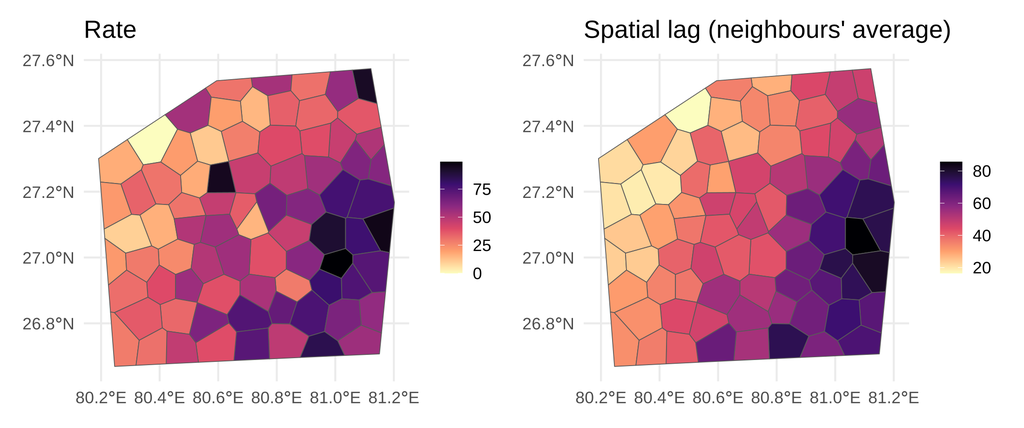

# Topic 3 — Does the choice matter?

## Sensitivity

```r
w_list <- list(queen = nb2listw(nb_q, style = "W", zero.policy = TRUE), rook = nb2listw(nb_r, style = "W", zero.policy = TRUE),
               knn5 = nb2listw(knn5, style = "W"), distance = nb2listw(nb_d, style = "W"))
map_dfr(w_list, \(w) { m <- moran.test(blocks$dengue_per_100k, w, zero.policy = TRUE); tibble(I = round(unname(m$estimate[1]), 3), p = signif(m$p.value, 2)) }, .id = "weights")
```

```
# A tibble: 4 × 3
  weights      I        p
  <chr>    <dbl>    <dbl>
1 queen    0.499 5   e-14
2 rook     0.499 5   e-14
3 knn5     0.511 1.80e-15
4 distance 0.543 1   e- 9
```

- Here the pattern is strong, so the conclusion barely moves
- With a **weak** pattern the answer can change with the weights
- **Justify** the choice with the biology: how far does a mosquito, a patient or an exposure travel?
- **Report** the weights and check sensitivity

## Common mistakes

- Using the default without saying which one
- Ignoring isolates (silently dropping areas) or areas with 15 neighbours
- Using contiguity for **points** (they have no boundaries)
- Computing distances in **degrees** instead of a projected CRS

## 🔧 Switch to R — Lab 2

**File:** `gis-workshop/labs/lab2_weights.R`

- `poly2nb()` queen vs rook · `summary()` of a neighbour list
- `knearneigh()` · `nb2listw()` · row sums
- `lag.listw()` and a check by hand · Moran’s I under four weights

**Time:** 30 minutes · answer the Q questions in the comments

## Self-check quiz (1/5)

In row-standardised weights, what do the weights of one area add up to?

- The number of neighbours of that area
- 0, because the weights cancel out
- 1, whatever the number of neighbours
- The area’s value divided by its population

## Self-check quiz (2/5)

An area has 4 neighbours and row-standardised weights. What is its spatial lag?

- The sum of its 4 neighbours’ values
- The mean of its 4 neighbours’ values
- Its own value minus the district mean
- The value of its single nearest neighbour

## Self-check quiz (3/5)

Why are queen contiguity neighbours a poor choice for point data such as patient homes?

- Points tend to have more than ten neighbours each
- Queen contiguity needs the data in degrees, not in metres
- Points have no boundaries to share, so contiguity does not exist
- Contiguity can only be calculated for blocks with no missing data

## Self-check quiz (4/5)

summary(nb) reports one region with no neighbours (an island). What is the safest response?

- Delete the region quietly so that the test runs without a warning
- Give it the average value of the whole district to fill the gap
- Ignore it, since one single area will not change the results
- Check it is real, then link it sensibly or use zero.policy

## Self-check quiz (5/5)

Moran’s I is 0.48 with queen weights and 0.12 with a distance band of 3 km. What is the best conclusion?

- It depends on the weights, so justify the choice and report sensitivity
- Queen weights are the standard choice, so the 3 km result can simply be ignored
- The two values should be averaged to give the true value of Moran’s I
- The analysis has failed, so the test should be dropped from the report

## Score and take-home

**Your score:**

- Weights turn ‘near’ into numbers; **choose them deliberately**
- **Row-standardised** weights make the lag the **average of neighbours**
- Check **isolates** and areas with very many neighbours
- **Report** the weights and test sensitivity

**Next:** Session 3: global spatial autocorrelation